# Lab6_Team B

Hangyeol Seon, Juchan Lee, Gunuk Nam, Jihwan Lee, Hanbin Lim

2023-05-02

### Loading data into R

```r
PRSA_data <- load("PRSA_data.RData")
head(train_data, 11)
```

```
##    No Month TEMP   Iws  time pm2.5
## 1   1   Jan  -11  1.79 night  <NA>
## 2   2   Jan  -12  4.92 night  <NA>
## 3   3   Jan  -11  6.71 night  <NA>
## 4   4   Jan  -14  9.84 night  <NA>
## 5   5   Jan  -12 12.97 night  <NA>
## 6   6   Jan  -10 16.10 night  <NA>
## 7   7   Jan   -9 19.23 night  <NA>
## 8   8   Jan   -9 21.02 night  <NA>
## 9   9   Jan   -9 24.15 night  <NA>
## 10 10   Jan   -8 27.28 night  <NA>
## 11 11   Jan   -7 31.30   day  <NA>
```

## <Question 1>

1. check the type of the train and test data, and NA value also.
2. exclude observations that pm2.5 is not available(NA).

```r
str(train_data)
```

```
## Classes 'tbl_df', 'tbl' and 'data.frame':    35064 obs. of  6 variables:
##  $ No   : num  1 2 3 4 5 6 7 8 9 10 ...
##  $ Month: Factor w/ 12 levels "Apr","Aug","Dec",..: 5 5 5 5 5 5 5 5 5 5 ...
##  $ TEMP : num  -11 -12 -11 -14 -12 -10 -9 -9 -9 -8 ...
##  $ Iws  : num  1.79 4.92 6.71 9.84 12.97 ...
##  $ time : Factor w/ 2 levels "day","night": 2 2 2 2 2 2 2 2 2 2 ...
##  $ pm2.5: Factor w/ 2 levels "HIGH","LOW": NA NA NA NA NA NA NA NA NA NA ...
```

```r
str(test_data)
```

```
## Classes 'tbl_df', 'tbl' and 'data.frame':    8760 obs. of  6 variables:
##  $ No   : num  35065 35066 35067 35068 35069 ...
##  $ Month: Factor w/ 12 levels "Apr","Aug","Dec",..: 5 5 5 5 5 5 5 5 5 5 ...
##  $ TEMP : num  7 7 6 6 3 4 6 6 6 7 ...
##  $ Iws  : num  143.48 147.5 151.52 153.31 0.89 ...
##  $ time : Factor w/ 2 levels "day","night": 2 2 2 2 2 2 2 2 2 2 ...
##  $ pm2.5: Factor w/ 2 levels "HIGH","LOW": 2 2 2 2 1 1 1 1 2 2 ...
```

```r
sum(is.na(test_data$pm2.5))
```

```
## [1] 99
```

```r
sum(is.na(train_data$pm2.5))
```

```
## [1] 1968
```

```r
test_data<- na.omit(test_data)
train_data<- na.omit(train_data)

sum(is.na(test_data$pm2.5))
```

```
## [1] 0
```

```r
sum(is.na(train_data$pm2.5))
```

```
## [1] 0
```

```r
table(train_data$Month)
```

```
##
##  Apr  Aug  Dec  Feb  Jan  Jul  Jun  Mar  May  Nov  Oct  Sep
## 2688 2604 2825 2704 2734 2910 2702 2813 2867 2795 2836 2618
```

```r
table(test_data$Month)
```

```
##
## Apr Aug Dec Feb Jan Jul Jun Mar May Nov Oct Sep
## 717 733 716 669 737 737 703 743 742 706 743 715
```

### explain

- str()를 활용해서 train과 test의 타입을 확인한다.
- test와 train의 pm2.5 중 NA값을 is.na와 sum을 활용해 더하며 개수를 확인한다.
- na.omit을 활용해 NA값을 제거한다.
- table함수를 활용해 달마다 분포도를 확인해본다. 결과를 보면 골고루 나와있는 것을 확인할 수 있다.

## <Question 2-1>

Month변수를 활용하여 pm2.5를 예측하는 Single Variable 모델 만들기.

```r
threshold <- 0.5
tble <- table(train_data$Month, train_data$pm2.5)
model_month <- prop.table(tble, margin = 1)[,1]
train_data$est_prob <- model_month[train_data$Month]
train_data$prediction <- train_data$est_prob > threshold
conf.table <- table(pred = train_data$prediction,
                    actual = train_data$pm2.5)
conf.table
```

```
##        actual
## pred     HIGH   LOW
##   FALSE 11619 13161
##   TRUE   4626  3690
```

```r
accracy <- sum(conf.table[1,2], conf.table[2,1]) / sum(conf.table)
accracy  # 0.537 for train data
```

```
## [1] 0.5374365
```

```r
test_data$est_prob <- model_month[test_data$Month]
test_data$prediction <- test_data$est_prob > threshold
conf.table <- table(pred = test_data$prediction,
                    actual = test_data$pm2.5)
accuracy_month <- sum(conf.table[1,2], conf.table[2,1]) / sum(conf.table)
accuracy_month # 0.51 for test data
```

```
## [1] 0.5102182
```

### explain

- Month변수에 대한 예측을 한다.
- prop.table를 사용하며, 1열이 pm2.5가 HIGH(TRUE) 열이므로, 1열만 뽑아서, model_month를 만든다.
- est_prob라는 변수에 model_month에서 각 카테고리 별로 나온 수치를 부여한다.
- prediction열에는 est_prob와 사전에 정의한 threshold와 비교하여 해당 threshold 기준으로 TRUE, FALSE를 구분한다.
- prediction변수와 목적변수인 pm2.5를 이용해 conf.table를 구성하고, accuracy는 (TP+TN) / total로 구할 수 있기 때문에 conf.table를 살펴보면서 식을 작성하여 accuracy를 구한다.
- 이 때 train뿐만 아니라 test 데이터에도 적용을 하는데 model_month는 train_data에서 만들어진 것을 활용한다.

## <Question 2-2>

calculate AUC and plot ROC curve

```r
library(ROCR)
calAUC <- function(predCol, targetCol) {
  perf <- performance(prediction(predCol, targetCol), 'auc')
  round(as.numeric(perf@y.values), digits = 2)
}
train_data$pm2.5_bl <- train_data$pm2.5
test_data$pm2.5_bl <- test_data$pm2.5
levels(train_data$pm2.5_bl) <- c(TRUE, FALSE)
levels(test_data$pm2.5_bl) <- c(TRUE, FALSE)
# 0.55 for AUC of train data
print(paste("AUC value for train data",
            calAUC(train_data$est_prob, train_data$pm2.5_bl)))
```

```
## [1] "AUC value for train data 0.55"
```

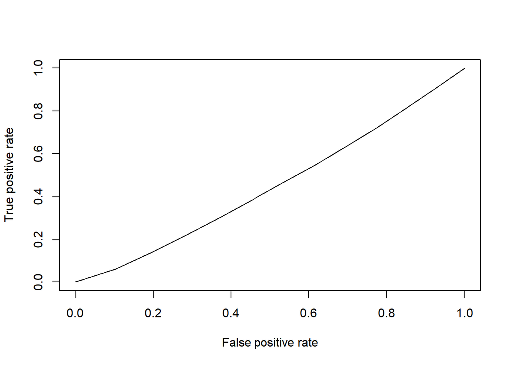

```r
plot(performance(prediction(train_data$est_prob,
                            train_data$pm2.5), 'tpr', 'fpr'))
```

```r
# 0.48 for AUC of test data
print(paste("AUC value for test data",
            calAUC(test_data$est_prob, test_data$pm2.5_bl)))
```

```
## [1] "AUC value for test data 0.48"
```

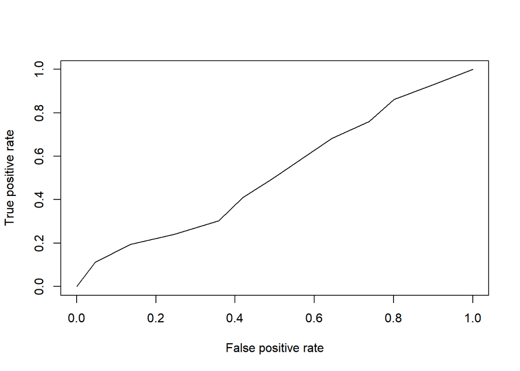

```r
plot(performance(prediction(test_data$est_prob,
                            test_data$pm2.5), 'tpr', 'fpr'))
```

### explain

- ROC curve를 그리기 위해 `{r} library(ROCR)`를 실행한다.
- calAUC는 auc value를 구하기 위한 function인데 `{r}prediction`함수에서 분류모델의 예측결과와 실제 데이터를 기록하고, 이를 이용해 `{r}performance & 'auc'`해당 함수와 ’auc’인자를 사용하여, auc값을 계산한다. `{r}perf@y.values`으로 perf 객체의 y.values멤버에 접근하여 digits를 설정하여 auc값을 나타낸다.
- calAUC의 두번째 인자에는 T/F 즉 boolean값이 들어가야 하므로, pm2.5을 불리언 값으로 변환한 열을 새로 만들고 해당 열을 calAUC함수에 적용하였다.
- plot함수를 이용해, ROC curve를 그렸으며, 위에서 나온 AUC값은 ROC curve의 line 기준 아래 면적을 뜻한다.

## <Question 2-4>

find how the precision and recall are changing

```r
result <- data.frame()
thre <- c(0.45, 0.47, 0.49, 0.51, 0.53, 0.55)
for (i in 1:length(thre)) {
  threshold <- thre[i]
  train_data$prediction <- train_data$est_prob > threshold
  conf.table <- table(pred = train_data$prediction,
                      actual = train_data$pm2.5)
  precision <- conf.table[2,1] / sum(conf.table[2,])
  recall <- conf.table[2,1] / sum(conf.table[,1])
  result <- rbind(result, c(threshold, precision, recall))
}
colnames(result) <- c("threshold", "precision", "recall")
result
```

```
##   threshold precision    recall
## 1      0.45 0.5081895 0.7773469
## 2      0.47 0.5141133 0.6973838
## 3      0.49 0.5257084 0.5356110
## 4      0.51 0.5562771 0.2847645
## 5      0.53 0.5746614 0.1985226
## 6      0.55 0.6217617 0.1034164
```

### explain

- for문으로 각 threshold마다의 precision과 recall을 확인한다.
- 처음에 빈 데이터프레임을 만들며, threshold의 영향이 가는 변수는 prediction변수이기 때문에, prediction변수와 conf.table을 계속해서 업데이트 한다.
- precision: TP / (TP+FP)
- recall: TP / (TP+FN)
- 위 계산식을 바탕으로 conf.table에서 적절한 위치를 찾으며 계산하여, 처음에 만든 result라는 데이터프레임에 rbind함수를 활용하여 계속해서 추가한다.
- 마지막에 열 이름을 각 변수에 맞게 설정하여 출력한다.

## <Question 2-5>

how to set the best threshold?

### explain

- 일반적으로 precision과 recall은 trade-off한 관계이기 때문에 모델이 완벽하거나 엄청 좋지 않은 이상, 두 값이 동시에 좋아지기는 어렵다.
- 단, 좋은 threshold를 설정하기 위해서는 precision 및 recall 두 값 모두 높게 나왔을 때의 threshold로 정하는게 타당하다고 생각한다.
- 궁극적으로 precision & recall == 1일 때, 가장 완벽한 모델이며, accuracy 또한 1이며 완벽하다고 할 수 있기 때문에, precision 및 recall 모두 높으면 높아질 수록 좋은 모델이라 평가할 수 있을 것이다.

## <Question 2-6>

calculate F1_score

```r
result$F1_score <- 2 * ((result$precision * result$recall) /
                          (result$precision + result$recall))
result
```

```
##   threshold precision    recall  F1_score
## 1      0.45 0.5081895 0.7773469 0.6145909
## 2      0.47 0.5141133 0.6973838 0.5918863
## 3      0.49 0.5257084 0.5356110 0.5306135
## 4      0.51 0.5562771 0.2847645 0.3766948
## 5      0.53 0.5746614 0.1985226 0.2951000
## 6      0.55 0.6217617 0.1034164 0.1773368
```

### explain

- F1_score: 2 * (precision * recall) / (precision + recall)
- 위 계산식에 precision열과 recall열을 적용하여, 각 threshold에 대한 F1_score를 계산하여 데이터프레임에 추가한다.

## <Question 3>

Repeat the tasks in Question 2 using the TEMP variable

```r
threshold <- 0.5

# set criteria for TEMP variable
train_data$TEMP_grp <- cut(train_data$TEMP,
                          breaks = c(-20, -10, 0, 10, 20, 30, Inf),
                          labels = c('too cold', 'cold', 'cool', 'warm', 'hot', 'too hot'),
                          right = F)
test_data$TEMP_grp <- cut(test_data$TEMP,
                           breaks = c(-20, -10, 0, 10, 20, 30, Inf),
                           labels = c('too cold', 'cold', 'cool', 'warm', 'hot', 'too hot'),
                           right = F)
```

### explain

- TEMP변수가 연속형 변수이기 때문에, cut함수를 사용하여 범주화 시킨다. train, test 데이터셋 동일하게 적용한다.
- 각 구간을 온도에 따라 too cold, cold, cool, warm, hot, too hot으로 범주를 설정했다.

```r
tble_TEMP <- table(train_data$TEMP_grp, train_data$pm2.5)
model_TEMP_grp <- prop.table(tble_TEMP, margin = 1)[,1]
train_data$est_prob <- model_TEMP_grp[train_data$TEMP_grp]
train_data$prediction <- train_data$est_prob > threshold
conf.table <- table(pred = train_data$prediction,
                    actual = train_data$pm2.5)
conf.table
```

```
##        actual
## pred     HIGH   LOW
##   FALSE 10827 12449
##   TRUE   5418  4402
```

```r
accracy <- sum(conf.table[1,2], conf.table[2,1]) / sum(conf.table)
accracy  # 0.54 for train data
```

```
## [1] 0.5398538
```

```r
test_data$est_prob <- model_TEMP_grp[test_data$TEMP_grp]
test_data$prediction <- test_data$est_prob > threshold
conf.table <- table(pred = test_data$prediction,
                    actual = test_data$pm2.5)
accuracy_TEMP <- sum(conf.table[1,2], conf.table[2,1]) / sum(conf.table)
accuracy_TEMP # 0.505 for test data
```

```
## [1] 0.505138
```

```r
# 0.55 for AUC of train data
print(paste("AUC value for train data",
            calAUC(train_data$est_prob, train_data$pm2.5_bl)))
```

```
## [1] "AUC value for train data 0.55"
```

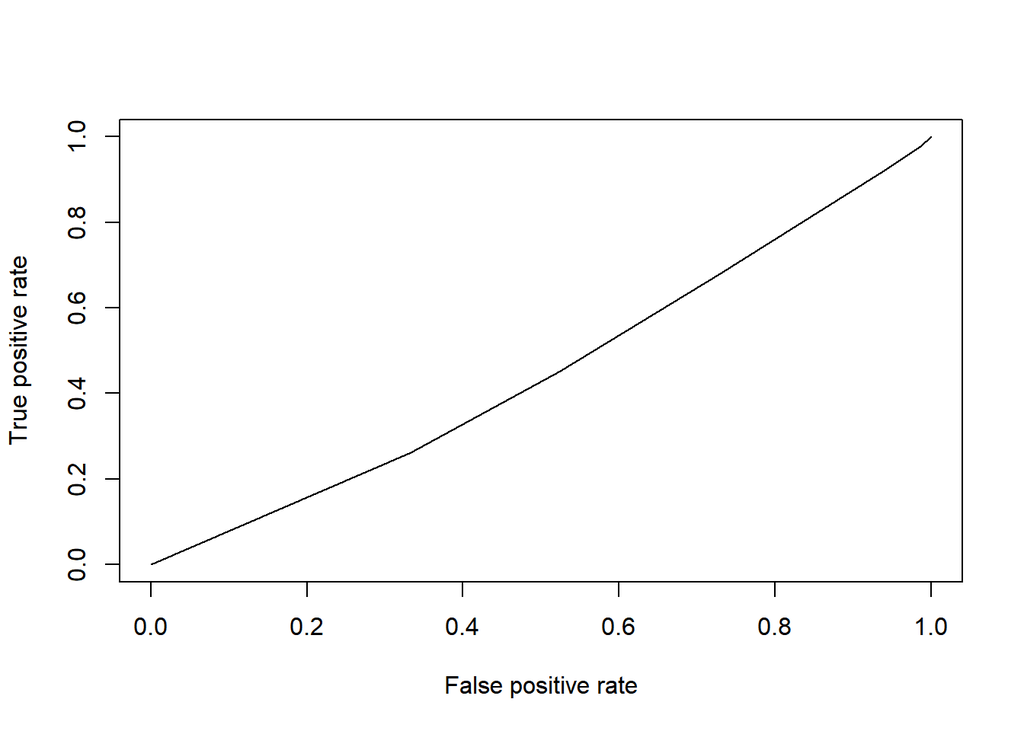

```r
plot(performance(prediction(train_data$est_prob,
                            train_data$pm2.5), 'tpr', 'fpr'))
```

```r
# 0.53 for AUC of test data
print(paste("AUC value for test data",
            calAUC(test_data$est_prob, test_data$pm2.5_bl)))
```

```
## [1] "AUC value for test data 0.53"
```

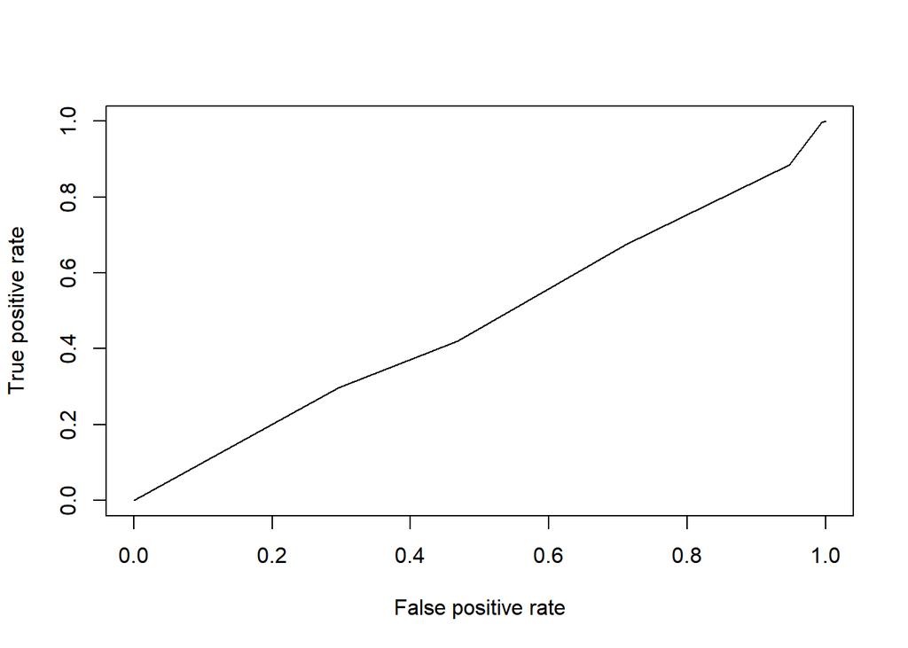

```r
plot(performance(prediction(test_data$est_prob,
                            test_data$pm2.5), 'tpr', 'fpr'))
```

### explain

- train, test 두 데이터셋에 대해서 accuracy를 계산한다.
- calAUC함수를 사용해서 두 데이터셋에 대한 AUC또한 계산하며, ROC curve를 그린다.
- accracy: train - 0.54, test - 0.505
- AUC: train - 0.55, test - 0.53

```r
result_TEMP <- data.frame()
summary(test_data$est_prob)
```

```
##    Min. 1st Qu.  Median    Mean 3rd Qu.    Max.
##  0.3591  0.4573  0.4648  0.4908  0.5517  0.5517
```

```r
thre <- c(0.40, 0.43, 0.46, 0.49, 0.52)
for (i in 1:length(thre)) {
  threshold <- thre[i]
  test_data$prediction <- test_data$est_prob > threshold
  conf.table <- table(pred = test_data$prediction,
                      actual = test_data$pm2.5)
  precision <- conf.table[2,1] / sum(conf.table[2,])
  recall <- conf.table[2,1] / sum(conf.table[,1])
  result_TEMP <- rbind(result_TEMP, c(threshold, precision, recall))
}
colnames(result_TEMP) <- c("threshold", "precision", "recall")
result_TEMP
```

```
##   threshold precision    recall
## 1      0.40 0.4844692 0.9945277
## 2      0.43 0.4844692 0.9945277
## 3      0.46 0.4979170 0.7109208
## 4      0.49 0.4838584 0.2959791
## 5      0.52 0.4838584 0.2959791
```

```r
result_TEMP$F1_score <- 2 * ((result_TEMP$precision * result_TEMP$recall) /
                          (result_TEMP$precision + result_TEMP$recall))
result_TEMP
```

```
##   threshold precision    recall  F1_score
## 1      0.40 0.4844692 0.9945277 0.6515470
## 2      0.43 0.4844692 0.9945277 0.6515470
## 3      0.46 0.4979170 0.7109208 0.5856527
## 4      0.49 0.4838584 0.2959791 0.3672867
## 5      0.52 0.4838584 0.2959791 0.3672867
```

### explain

- summary함수를 사용하여 est_prob변수의 분포를 확인하여 적당한 threshold 범위를 정한다.
- for문을 이용하여 threshold별 precision과 recall를 계산하여 데이터프레임을 만들고, 마지막에 F1_score를 계산한다.

## <Question 4>

Repeat the tasks in Question 2 using the Iws variable

```r
# Check the distribution of Iws variable
library(tidyverse)
summary(train_data$Iws)
```

```
##    Min. 1st Qu.  Median    Mean 3rd Qu.    Max.
##    0.45    1.79    5.81   25.02   23.26  565.49
```

```r
str(train_data$Iws)
```

```
##  num [1:33096] 1.79 2.68 3.57 5.36 6.25 ...
```

```r
train_data %>%
  group_by(Month) %>%
  summarize(mean_Iws = mean(Iws),
            sd_Iws = sd(Iws),
            median_Iws = median(Iws),
            min_Iws = min(Iws),
            max_Iws = max(Iws))
```

```
## # A tibble: 12 × 6
##    Month mean_Iws sd_Iws median_Iws min_Iws max_Iws
##    <fct>    <dbl>  <dbl>      <dbl>   <dbl>   <dbl>
##  1 Apr       39.4   60.0      14.3     0.45   435.
##  2 Aug       13.1   19.6       4.92    0.45   160.
##  3 Dec       40.1   77.1       6.26    0.45   565.
##  4 Feb       18.4   36.4       5.37    0.45   344.
##  5 Jan       36.9   69.4       7.6     0.45   446.
##  6 Jul       12.5   15.7       4.92    0.45    97.0
##  7 Jun       11.8   18.1       4.92    0.45   207.
##  8 Mar       30.6   51.5       8.94    0.45   356.
##  9 May       26.6   42.2       8.94    0.45   304.
## 10 Nov       42.5   82.0       4.92    0.45   490.
## 11 Oct       15.4   31.0       3.56    0.45   278.
## 12 Sep       11.9   23.0       3.58    0.45   254.
```

```r
# use cut function because Iws variable is continuous variable
train_data$Iws_grp <- cut(train_data$Iws,
                          breaks = c(0, 5, 10, 15, 20, 25, 30, 35, 40, 45, 50, Inf),
                          labels = c('under5', '5~10','10~15','15~20','20~25',
                                     '25~30','30~35','35~40','40~45','45~50','over50'),
                          right = F)
test_data$Iws_grp <- cut(test_data$Iws,
                          breaks = c(0, 5, 10, 15, 20, 25, 30, 35, 40, 45, 50, Inf),
                          labels = c('under5', '5~10','10~15','15~20','20~25',
                                     '25~30','30~35','35~40','40~45','45~50','over50'),
                          right = F)
```

### explain

```r
threshold <- 0.5
tble_Iws <- table(train_data$Iws_grp, train_data$pm2.5)
model_Iws_grp <- prop.table(tble_Iws, margin = 1)[,1]
train_data$est_prob <- model_Iws_grp[train_data$Iws_grp]
train_data$prediction <- train_data$est_prob > threshold
conf.table <- table(pred = train_data$prediction,
                    actual = train_data$pm2.5)
conf.table
```

```
##        actual
## pred     HIGH   LOW
##   FALSE  4499  8738
##   TRUE  11746  8113
```

```r
accracy <- sum(conf.table[1,2], conf.table[2,1]) / sum(conf.table)
accracy  # 0.619 for train data
```

```
## [1] 0.6189268
```

```r
test_data$est_prob <- model_Iws_grp[test_data$Iws_grp]
test_data$prediction <- test_data$est_prob > threshold
conf.table <- table(pred = test_data$prediction,
                    actual = test_data$pm2.5)
accuracy_Iws <- sum(conf.table[1,2], conf.table[2,1]) / sum(conf.table)
accuracy_Iws # 0.586 for test data
```

```
## [1] 0.586191
```

```r
# 0.65 for AUC of train data
print(paste("AUC value for train data",
            calAUC(train_data$est_prob, train_data$pm2.5_bl)))
```

```
## [1] "AUC value for train data 0.65"
```

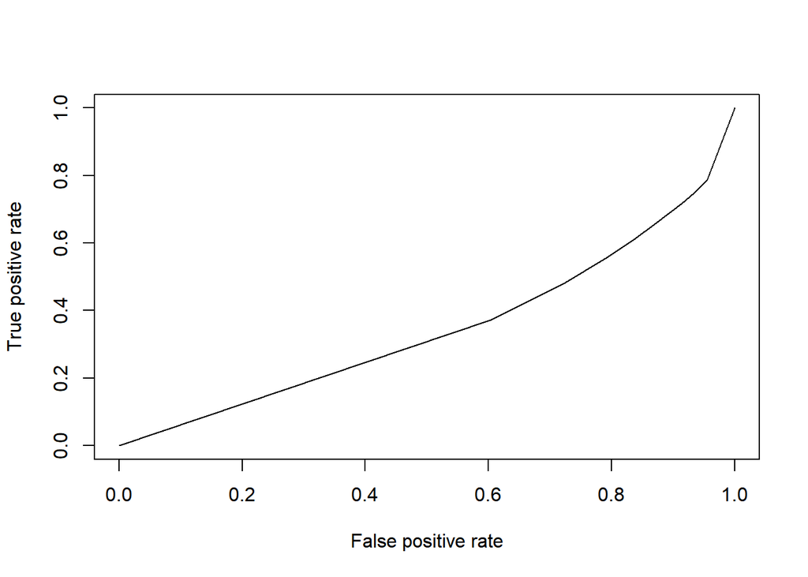

```r
plot(performance(prediction(train_data$est_prob,
                            train_data$pm2.5), 'tpr', 'fpr'))
```

```r
# 0.62 for AUC of test data
print(paste("AUC value for test data",
            calAUC(test_data$est_prob, test_data$pm2.5_bl)))
```

```
## [1] "AUC value for test data 0.62"
```

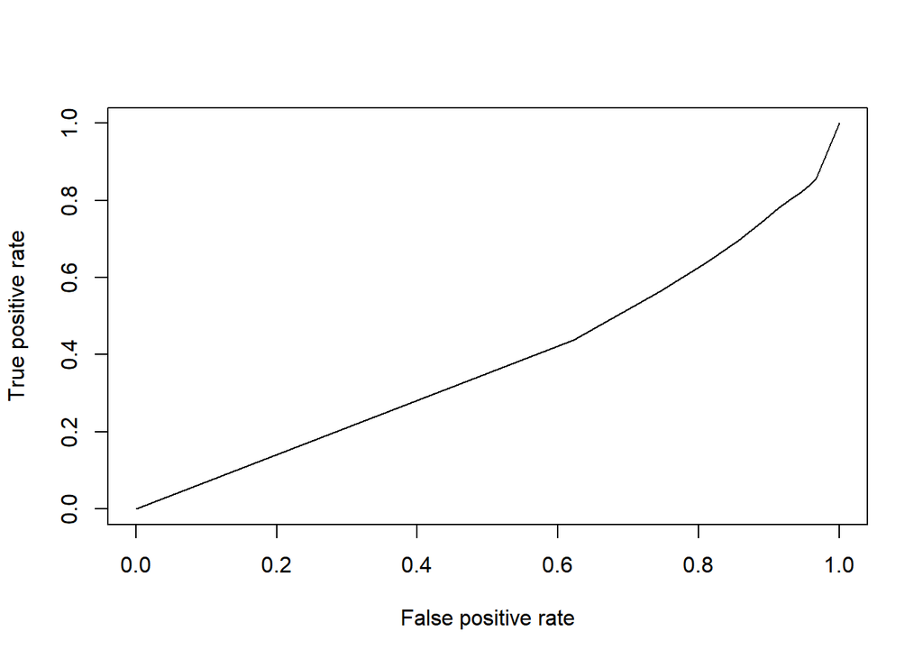

```r
plot(performance(prediction(test_data$est_prob,
                            test_data$pm2.5), 'tpr', 'fpr'))
```

### explain

- train, test 두 데이터셋에 대해서 accuracy를 계산한다.
- calAUC함수를 사용해서 두 데이터셋에 대한 AUC또한 계산하며, ROC curve를 그린다.
- accracy: train - 0.619, test - 0.586
- AUC: train - 0.65, test - 0.62

```r
result_Iws <- data.frame()
summary(test_data$est_prob)
```

```
##    Min. 1st Qu.  Median    Mean 3rd Qu.    Max.
##  0.1682  0.4433  0.6096  0.5105  0.6096  0.6096
```

```r
thre <- c(0.30, 0.40, 0.50, 0.60)
for (i in 1:length(thre)) {
  threshold <- thre[i]
  test_data$prediction <- test_data$est_prob > threshold
  conf.table <- table(pred = test_data$prediction,
                      actual = test_data$pm2.5)
  precision <- conf.table[2,1] / sum(conf.table[2,])
  recall <- conf.table[2,1] / sum(conf.table[,1])
  result_Iws <- rbind(result_Iws, c(threshold, precision, recall))
}
colnames(result_Iws) <- c("threshold", "precision", "recall")
result_Iws
```

```
##   threshold precision    recall
## 1       0.3 0.5152207 0.9664525
## 2       0.4 0.5245969 0.9133952
## 3       0.5 0.5548079 0.7454199
## 4       0.6 0.5725542 0.6224126
```

```r
result_Iws$F1_score <- 2 * ((result_Iws$precision * result_Iws$recall) /
                          (result_Iws$precision + result_Iws$recall))
result_Iws
```

```
##   threshold precision    recall  F1_score
## 1       0.3 0.5152207 0.9664525 0.6721271
## 2       0.4 0.5245969 0.9133952 0.6664352
## 3       0.5 0.5548079 0.7454199 0.6361421
## 4       0.6 0.5725542 0.6224126 0.5964432
```

### explain

- summary함수를 사용하여 est_prob변수의 분포를 확인하여 적당한 threshold 범위를 정한다.
- for문을 이용하여 threshold별 precision과 recall를 계산하여 데이터프레임을 만들고, 마지막에 F1_score를 계산한다.

## <Question 5>

Repeat the tasks in Question 2 using the time variable

```r
threshold <- 0.5
tble_time <- table(train_data$time, train_data$pm2.5)
model_time <- prop.table(tble_time, margin = 1)[,1]
train_data$est_prob <- model_time[train_data$time]
train_data$prediction <- train_data$est_prob > threshold
conf.table <- table(pred = train_data$prediction,
                    actual = train_data$pm2.5)
conf.table
```

```
##        actual
## pred     HIGH   LOW
##   FALSE  5572  6833
##   TRUE  10673 10018
```

```r
accracy <- sum(conf.table[1,2], conf.table[2,1]) / sum(conf.table)
accracy  # 0.529 for train data
```

```
## [1] 0.5289461
```

```r
test_data$est_prob <- model_time[test_data$time]
test_data$prediction <- test_data$est_prob > threshold
conf.table <- table(pred = test_data$prediction,
                    actual = test_data$pm2.5)
accuracy_time <- sum(conf.table[1,2], conf.table[2,1]) / sum(conf.table)
accuracy_time # 0.536 for test data
```

```
## [1] 0.5356194
```

```r
# 0.53 for AUC of train data
print(paste("AUC value for train data",
            calAUC(train_data$est_prob, train_data$pm2.5_bl)))
```

```
## [1] "AUC value for train data 0.53"
```

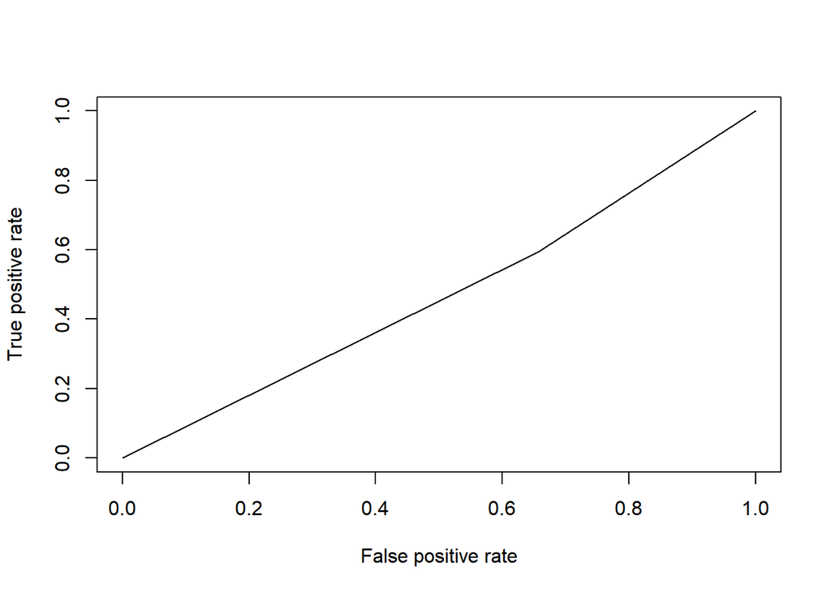

```r
plot(performance(prediction(train_data$est_prob,
                            train_data$pm2.5), 'tpr', 'fpr'))
```

```r
# 0.54 for AUC of test data
print(paste("AUC value for test data",
            calAUC(test_data$est_prob, test_data$pm2.5_bl)))
```

```
## [1] "AUC value for test data 0.54"
```

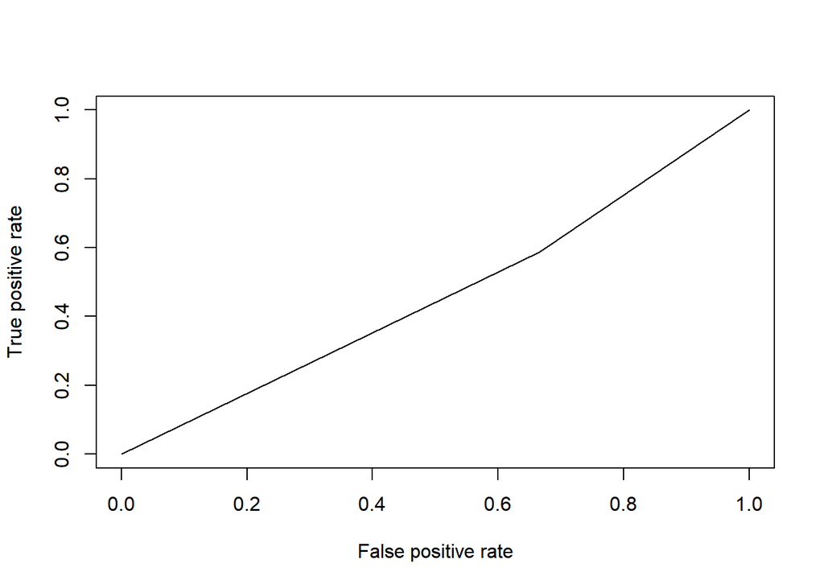

```r
plot(performance(prediction(test_data$est_prob,
                            test_data$pm2.5), 'tpr', 'fpr'))
```

### explain

- time변수는 day & night인 두 카테고리밖에 없기 때문에, 따로 범주화 시킬 필요는 없다.
- train, test 두 데이터셋에 대해서 accuracy를 계산한다.
- calAUC함수를 사용해서 두 데이터셋에 대한 AUC또한 계산하며, ROC curve를 그린다.
- accracy: train - 0.529, test - 0.536
- AUC: train - 0.53, test - 0.54

```r
# there is only two values in time column, so threshold is given only 0.5
result_time <- data.frame()
precision <- conf.table[2,1] / sum(conf.table[2,])
recall <- conf.table[2,1] / sum(conf.table[,1])
result_time <- rbind(result_time, c(threshold, precision, recall))
colnames(result_time) <- c("threshold", "precision", "recall")
result_time
```

```
##   threshold precision    recall
## 1       0.5 0.5167005 0.6661908
```

```r
result_time$F1_score <- 2 * ((result_time$precision * result_time$recall) /
                          (result_time$precision + result_time$recall))
result_time
```

```
##   threshold precision    recall  F1_score
## 1       0.5 0.5167005 0.6661908 0.5819996
```

### explain

- 위에서도 언급했듯이 level 개수가 두 개 뿐이므로 threshold 또한 하나만 설정하면 되기 때문에 따로 for문을 설정하지 않고 하나의 threshold에 대한 precision과 recall만 계산한다.
- 추가로 F1_score까지 계산하여 데이터프레임을 만든다.

## <Question 6>

what is the best performing prediction model for pm2.5?

```r
# accuracy of the test data
accuracy_month
```

```
## [1] 0.5102182
```

```r
accuracy_TEMP
```

```
## [1] 0.505138
```

```r
accuracy_Iws
```

```
## [1] 0.586191
```

```r
accuracy_time
```

```
## [1] 0.5356194
```

```r
# AUC of the test data
"
Month: 0.48
TEMP: 0.53
Iws: 0.62
time: 0.54
"
```

```
## [1] "\nMonth: 0.48\nTEMP: 0.53\nIws: 0.62\ntime: 0.54\n"
```

```r
# precision, recall & F1-score
result
```

```
##   threshold precision    recall  F1_score
## 1      0.45 0.5081895 0.7773469 0.6145909
## 2      0.47 0.5141133 0.6973838 0.5918863
## 3      0.49 0.5257084 0.5356110 0.5306135
## 4      0.51 0.5562771 0.2847645 0.3766948
## 5      0.53 0.5746614 0.1985226 0.2951000
## 6      0.55 0.6217617 0.1034164 0.1773368
```

```r
result_TEMP
```

```
##   threshold precision    recall  F1_score
## 1      0.40 0.4844692 0.9945277 0.6515470
## 2      0.43 0.4844692 0.9945277 0.6515470
## 3      0.46 0.4979170 0.7109208 0.5856527
## 4      0.49 0.4838584 0.2959791 0.3672867
## 5      0.52 0.4838584 0.2959791 0.3672867
```

```r
result_Iws
```

```
##   threshold precision    recall  F1_score
## 1       0.3 0.5152207 0.9664525 0.6721271
## 2       0.4 0.5245969 0.9133952 0.6664352
## 3       0.5 0.5548079 0.7454199 0.6361421
## 4       0.6 0.5725542 0.6224126 0.5964432
```

```r
result_time
```

```
##   threshold precision    recall  F1_score
## 1       0.5 0.5167005 0.6661908 0.5819996
```

### explain

- 위 결과에서 볼 수 있듯이, Iws변수가 가장 높은 accuracy, AUC, F1_score 등의 성능을 보여주고 있다.
- 왜냐하면, pm2.5는 바람에 실려 날아오기 때문에, 바람과 가장 연관이 있는 누적 풍속을 나타내는 Iws가 다른 변수들에 비해서 가장 적합한 예측 변수라고 생각한다.
- 즉, pm2.5를 가장 잘 예측할 수 있는 예측변수는 Iws변수이다.